# Análisis evolución Covid-19 Chile casos y decesos (15/04/2020)

### Predicciones para serie total usando predicción por regiones.

Otro modelo posible de análisis es usar la suma de las predicciones parciales por región. No he calculado los intervalos de confianza, porque para que sean adecuados debería considerar la covarianza entre las series de las distintas regiones.

El modelo de sumas de T+AR(1) en 7 días predice 10863, nuevamente un 10% más que los modelos de serie total.

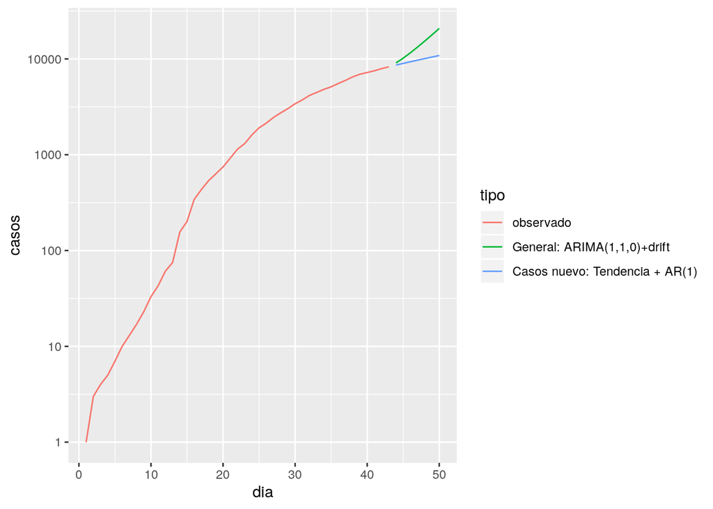

| dia | tipo | casos |
| --- | --- | --- |
| 1 | observado | 1 |
| 2 | observado | 3 |
| 3 | observado | 4 |
| 4 | observado | 5 |
| 5 | observado | 7 |
| 6 | observado | 10 |
| 7 | observado | 13 |
| 8 | observado | 17 |
| 9 | observado | 23 |
| 10 | observado | 33 |
| 11 | observado | 43 |
| 12 | observado | 61 |
| 13 | observado | 75 |
| 14 | observado | 156 |
| 15 | observado | 201 |
| 16 | observado | 342 |
| 17 | observado | 434 |
| 18 | observado | 537 |
| 19 | observado | 632 |
| 20 | observado | 746 |
| 21 | observado | 922 |
| 22 | observado | 1142 |
| 23 | observado | 1306 |
| 24 | observado | 1610 |
| 25 | observado | 1909 |
| 26 | observado | 2139 |
| 27 | observado | 2449 |
| 28 | observado | 2738 |
| 29 | observado | 3031 |
| 30 | observado | 3404 |
| 31 | observado | 3737 |
| 32 | observado | 4161 |
| 33 | observado | 4471 |
| 34 | observado | 4815 |
| 35 | observado | 5116 |
| 36 | observado | 5546 |
| 37 | observado | 5972 |
| 38 | observado | 6501 |
| 39 | observado | 6927 |
| 40 | observado | 7213 |
| 41 | observado | 7525 |
| 42 | observado | 7917 |
| 43 | observado | 8273 |
| 44 | General: ARIMA(1,1,0)+drift | 9080 |
| 45 | General: ARIMA(1,1,0)+drift | 10189 |
| 46 | General: ARIMA(1,1,0)+drift | 11596 |
| 47 | General: ARIMA(1,1,0)+drift | 13315 |
| 48 | General: ARIMA(1,1,0)+drift | 15388 |
| 49 | General: ARIMA(1,1,0)+drift | 17864 |
| 50 | General: ARIMA(1,1,0)+drift | 20810 |
| 44 | Casos nuevo: Tendencia + AR(1) | 8628 |
| 45 | Casos nuevo: Tendencia + AR(1) | 8980 |
| 46 | Casos nuevo: Tendencia + AR(1) | 9339 |
| 47 | Casos nuevo: Tendencia + AR(1) | 9704 |
| 48 | Casos nuevo: Tendencia + AR(1) | 10079 |
| 49 | Casos nuevo: Tendencia + AR(1) | 10465 |
| 50 | Casos nuevo: Tendencia + AR(1) | 10863 |

### Predicción por regiones

Eliminaremos la predicción de Atacama y Aysén, que presentan tasas estabilizadas Recordemos que el algoritmo inicia desde 2 casos en cada Región, agregando la predicción AR(4).

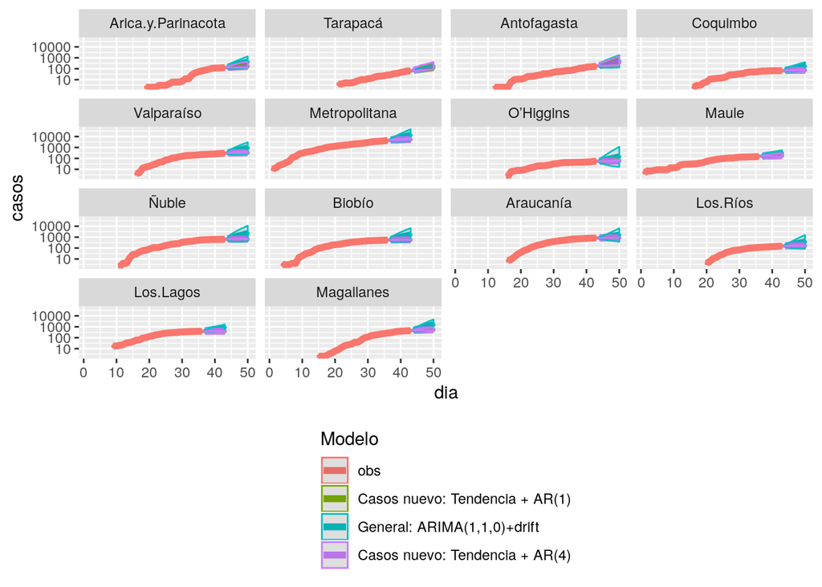

Las tablas por regiones se incluye en el Anexo I

## Decesos

Si observamos la serie de decesos, es clara la desaceleración en la serie total y Metropolitana, pero comienza a aumentar la tasa de Ñuble y Araucanía. Debemos esperar a ver que pasa con Magallanes.

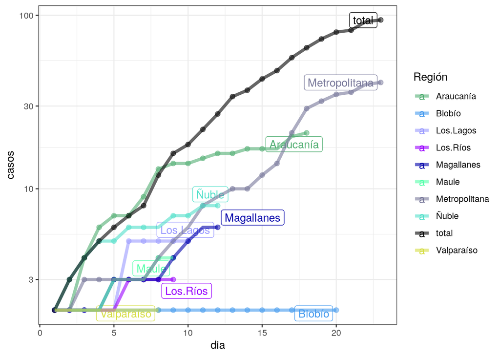

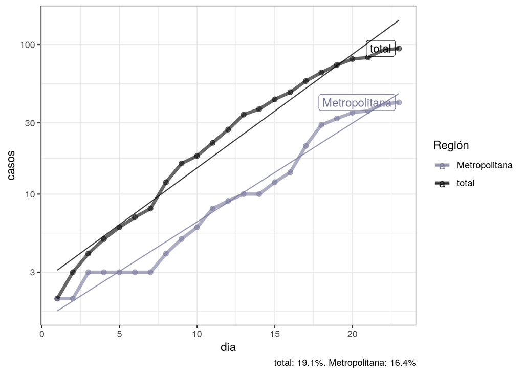

**Fuentes de información**: Principalmente, se utilizó el reporte diario del [MINSAL](https://www.minsal.cl/nuevo-coronavirus-2019-ncov/casos-confirmados-en-chile-covid-19/), usando [Wayback machine](https://archive.org/web/) para recopilar la información ya no disponible.

## Anexo I: Predicciones por región

Casos nuevos: tendencia + AR(1) : Arica.y.Parinacota

|  | dia | casos | li | ls |
| --- | --- | --- | --- | --- |
| **26** | 44 | 129.3 | 125 | 152.5 |
| **27** | 45 | 135 | 126 | 185.1 |
| **28** | 46 | 140.5 | 126.9 | 217.4 |
| **29** | 47 | 145.8 | 127.8 | 248.3 |
| **30** | 48 | 150.8 | 128.7 | 277.2 |
| **31** | 49 | 155.4 | 129.5 | 304 |
| **32** | 50 | 159.6 | 130.2 | 328.5 |

Casos nuevos: tendencia + AR(1) : Tarapacá

|  | dia | casos | li | ls |
| --- | --- | --- | --- | --- |
| **24** | 44 | 74.04 | 65.91 | 99.08 |
| **25** | 45 | 79.11 | 67.42 | 116.1 |
| **26** | 46 | 87.3 | 69.82 | 144 |
| **27** | 47 | 95.03 | 72.09 | 170.4 |
| **28** | 48 | 104.1 | 74.74 | 201.3 |
| **29** | 49 | 113.8 | 77.59 | 234.5 |
| **30** | 50 | 124.7 | 80.77 | 271.5 |

Casos nuevos: tendencia + AR(1) : Antofagasta

|  | dia | casos | li | ls |
| --- | --- | --- | --- | --- |
| **33** | 44 | 192.4 | 179.6 | 251.1 |
| **34** | 45 | 212.4 | 183.8 | 345.1 |
| **35** | 46 | 235.2 | 188.7 | 451.9 |
| **36** | 47 | 261.4 | 194.3 | 575.1 |
| **37** | 48 | 291.8 | 200.8 | 717.4 |
| **38** | 49 | 326.9 | 208.2 | 882.2 |
| **39** | 50 | 367.7 | 216.9 | 1074 |

Casos nuevos: tendencia + AR(1) : Atacama

|  | dia | casos | li | ls |
| --- | --- | --- | --- | --- |
| **19** | 44 | 13.88 | 13.44 | 14.77 |
| **20** | 45 | 14.67 | 13.83 | 16.36 |
| **21** | 46 | 15.36 | 14.17 | 17.76 |
| **22** | 47 | 15.95 | 14.46 | 18.97 |
| **23** | 48 | 16.46 | 14.71 | 20 |
| **24** | 49 | 16.9 | 14.93 | 20.87 |
| **25** | 50 | 17.26 | 15.1 | 21.6 |

Casos nuevos: tendencia + AR(1) : Coquimbo

|  | dia | casos | li | ls |
| --- | --- | --- | --- | --- |
| **29** | 44 | 67 | 66.23 | 70.32 |
| **30** | 45 | 67.83 | 66.42 | 74.03 |
| **31** | 46 | 68.55 | 66.58 | 77.19 |
| **32** | 47 | 69.15 | 66.72 | 79.85 |
| **33** | 48 | 69.65 | 66.83 | 82.06 |
| **34** | 49 | 70.06 | 66.92 | 83.89 |
| **35** | 50 | 70.4 | 67 | 85.37 |

Casos nuevos: tendencia + AR(1) : Valparaíso

|  | dia | casos | li | ls |
| --- | --- | --- | --- | --- |
| **29** | 44 | 305.1 | 300.8 | 319.5 |
| **30** | 45 | 311.1 | 302.6 | 339.6 |
| **31** | 46 | 316.1 | 304.1 | 356.8 |
| **32** | 47 | 320.5 | 305.4 | 371.5 |
| **33** | 48 | 324.2 | 306.5 | 384 |
| **34** | 49 | 327.3 | 307.4 | 394.4 |
| **35** | 50 | 329.8 | 308.1 | 403 |

Casos nuevos: tendencia + AR(1) : Metropolitana

|  | dia | casos | li | ls |
| --- | --- | --- | --- | --- |
| **37** | 37 | 4525 | 4411 | 4805 |
| **38** | 38 | 4696 | 4479 | 5237 |
| **39** | 39 | 4853 | 4541 | 5637 |
| **40** | 40 | 4999 | 4599 | 6007 |
| **41** | 41 | 5133 | 4652 | 6346 |
| **42** | 42 | 5255 | 4700 | 6655 |
| **43** | 43 | 5366 | 4743 | 6934 |

Casos nuevos: tendencia + AR(1) : O’Higgins

|  | dia | casos | li | ls |
| --- | --- | --- | --- | --- |
| **29** | 44 | 55.21 | 54.33 | 58.5 |
| **30** | 45 | 56.41 | 54.65 | 62.97 |
| **31** | 46 | 57.55 | 54.95 | 67.26 |
| **32** | 47 | 58.64 | 55.24 | 71.34 |
| **33** | 48 | 59.68 | 55.52 | 75.22 |
| **34** | 49 | 60.66 | 55.78 | 78.88 |
| **35** | 50 | 61.58 | 56.03 | 82.34 |

Casos nuevos: tendencia + AR(1) : Maule

|  | dia | casos | li | ls |
| --- | --- | --- | --- | --- |
| **37** | 37 | 156.5 | 152.9 | 174.4 |
| **38** | 38 | 160.2 | 153.6 | 193.5 |
| **39** | 39 | 163.7 | 154.3 | 211.2 |
| **40** | 40 | 167 | 155 | 227.7 |
| **41** | 41 | 170 | 155.6 | 243.3 |
| **42** | 42 | 172.8 | 156.1 | 257.7 |
| **43** | 43 | 175.5 | 156.6 | 271.1 |

Casos nuevos: tendencia + AR(1) : Ñuble

|  | dia | casos | li | ls |
| --- | --- | --- | --- | --- |
| **34** | 44 | 638.8 | 635.1 | 654.9 |
| **35** | 45 | 642.7 | 636 | 671.5 |
| **36** | 46 | 645.6 | 636.7 | 684.3 |
| **37** | 47 | 647.8 | 637.2 | 693.8 |
| **38** | 48 | 649.4 | 637.6 | 700.9 |
| **39** | 49 | 650.6 | 637.8 | 706 |
| **40** | 50 | 651.5 | 638 | 709.6 |

Casos nuevos: tendencia + AR(1) : Biobío

|  | dia | casos | li | ls |
| --- | --- | --- | --- | --- |
| **34** | 37 | 548.9 | 544.7 | 559.8 |
| **35** | 38 | 554.3 | 546.8 | 573.4 |
| **36** | 39 | 558.4 | 548.4 | 583.9 |
| **37** | 40 | 561.5 | 549.6 | 591.9 |
| **38** | 41 | 563.8 | 550.5 | 597.8 |
| **39** | 42 | 565.4 | 551.1 | 602.1 |
| **40** | 43 | 566.6 | 551.6 | 605.1 |

Casos nuevos: tendencia + AR(1) : Araucanía

|  | dia | casos | li | ls |
| --- | --- | --- | --- | --- |
| **29** | 44 | 834.7 | 830.5 | 842.7 |
| **30** | 45 | 841.2 | 833.9 | 855.4 |
| **31** | 46 | 846 | 836.4 | 864.5 |
| **32** | 47 | 849.4 | 838.1 | 871 |
| **33** | 48 | 851.7 | 839.3 | 875.6 |
| **34** | 49 | 853.3 | 840.1 | 878.6 |
| **35** | 50 | 854.3 | 840.7 | 880.6 |

Casos nuevos: tendencia + AR(1) : Los.Ríos

|  | dia | casos | li | ls |
| --- | --- | --- | --- | --- |
| **25** | 44 | 153.1 | 151.3 | 157.4 |
| **26** | 45 | 155.3 | 152.1 | 163 |
| **27** | 46 | 157.2 | 152.9 | 167.8 |
| **28** | 47 | 158.7 | 153.5 | 171.7 |
| **29** | 48 | 160 | 154 | 174.8 |
| **30** | 49 | 161 | 154.4 | 177.3 |
| **31** | 50 | 161.8 | 154.8 | 179.3 |

Casos nuevos: tendencia + AR(1) : Los.Lagos

|  | dia | casos | li | ls |
| --- | --- | --- | --- | --- |
| **29** | 37 | 392.8 | 391.2 | 396.6 |
| **30** | 38 | 395.1 | 392.1 | 402.5 |
| **31** | 39 | 396.7 | 392.7 | 406.5 |
| **32** | 40 | 397.8 | 393.1 | 409.4 |
| **33** | 41 | 398.5 | 393.4 | 411.2 |
| **34** | 42 | 399 | 393.6 | 412.5 |
| **35** | 43 | 399.3 | 393.7 | 413.2 |

Casos nuevos: tendencia + AR(1) : Aysén

|  | dia | casos | li | ls |
| --- | --- | --- | --- | --- |
| **22** | 44 | 7.93 | 7.67 | 8.28 |
| **23** | 45 | 8.84 | 8.33 | 9.54 |
| **24** | 46 | 9.73 | 8.98 | 10.77 |
| **25** | 47 | 10.6 | 9.61 | 11.97 |
| **26** | 48 | 11.45 | 10.22 | 13.14 |
| **27** | 49 | 12.27 | 10.81 | 14.27 |
| **28** | 50 | 13.06 | 11.39 | 15.37 |

Casos nuevos: tendencia + AR(1) : Magallanes

|  | dia | casos | li | ls |
| --- | --- | --- | --- | --- |
| **30** | 44 | 462.1 | 449 | 508.9 |
| **31** | 45 | 477.3 | 453.2 | 564.8 |
| **32** | 46 | 490.7 | 456.8 | 614.2 |
| **33** | 47 | 502.3 | 460 | 656.6 |
| **34** | 48 | 512 | 462.6 | 692.4 |
| **35** | 49 | 520.1 | 464.8 | 722.2 |
| **36** | 50 | 526.8 | 466.6 | 746.6 |

ARIMA(1,1,0) con deriva : Arica.y.Parinacota

|  | dia | casos | li | ls |
| --- | --- | --- | --- | --- |
| **26** | 44 | 146.6 | 94.97 | 226.1 |
| **27** | 45 | 173.9 | 93.26 | 324.4 |
| **28** | 46 | 206.5 | 95.82 | 445 |
| **29** | 47 | 245.1 | 100.8 | 596.3 |
| **30** | 48 | 291 | 107.5 | 787.5 |
| **31** | 49 | 345.4 | 115.9 | 1029 |
| **32** | 50 | 410.1 | 126 | 1335 |

ARIMA(1,1,0) con deriva : Tarapacá

|  | dia | casos | li | ls |
| --- | --- | --- | --- | --- |
| **24** | 44 | 71.99 | 60.12 | 86.21 |
| **25** | 45 | 81.34 | 64.45 | 102.7 |
| **26** | 46 | 92.37 | 69.9 | 122.1 |
| **27** | 47 | 104.8 | 76.27 | 144 |
| **28** | 48 | 118.9 | 83.6 | 169.2 |
| **29** | 49 | 134.9 | 91.91 | 198.1 |
| **30** | 50 | 153.1 | 101.3 | 231.4 |

ARIMA(1,1,0) con deriva : Antofagasta

|  | dia | casos | li | ls |
| --- | --- | --- | --- | --- |
| **33** | 44 | 202.5 | 134.1 | 305.9 |
| **34** | 45 | 233.6 | 123.3 | 442.4 |
| **35** | 46 | 269.6 | 119.7 | 607 |
| **36** | 47 | 311.1 | 119.7 | 808.7 |
| **37** | 48 | 359 | 121.9 | 1057 |
| **38** | 49 | 414.3 | 125.8 | 1365 |
| **39** | 50 | 478.1 | 131.1 | 1744 |

ARIMA(1,1,0) con deriva : Atacama

|  | dia | casos | li | ls |
| --- | --- | --- | --- | --- |
| **19** | 44 | 14.68 | 10.46 | 20.62 |
| **20** | 45 | 16.4 | 10.37 | 25.91 |
| **21** | 46 | 18.33 | 10.54 | 31.85 |
| **22** | 47 | 20.48 | 10.87 | 38.6 |
| **23** | 48 | 22.89 | 11.31 | 46.35 |
| **24** | 49 | 25.59 | 11.84 | 55.29 |
| **25** | 50 | 28.6 | 12.46 | 65.61 |

ARIMA(1,1,0) con deriva : Coquimbo

|  | dia | casos | li | ls |
| --- | --- | --- | --- | --- |
| **29** | 44 | 74.81 | 53.86 | 103.9 |
| **30** | 45 | 85.16 | 53.09 | 136.6 |
| **31** | 46 | 96.95 | 54.17 | 173.5 |
| **32** | 47 | 110.4 | 56.25 | 216.6 |
| **33** | 48 | 125.7 | 59.06 | 267.4 |
| **34** | 49 | 143.1 | 62.5 | 327.4 |
| **35** | 50 | 162.9 | 66.54 | 398.6 |

ARIMA(1,1,0) con deriva : Valparaíso

|  | dia | casos | li | ls |
| --- | --- | --- | --- | --- |
| **29** | 44 | 341.7 | 236.7 | 493.3 |
| **30** | 45 | 398.3 | 222.5 | 713 |
| **31** | 46 | 466.4 | 220.5 | 986.8 |
| **32** | 47 | 546.8 | 225.1 | 1329 |
| **33** | 48 | 641.1 | 234 | 1757 |
| **34** | 49 | 751.8 | 246.5 | 2293 |
| **35** | 50 | 881.6 | 262.1 | 2966 |

ARIMA(1,1,0) con deriva : Metropolitana

|  | dia | casos | li | ls |
| --- | --- | --- | --- | --- |
| **37** | 37 | 4907 | 3674 | 6555 |
| **38** | 38 | 5717 | 3445 | 9485 |
| **39** | 39 | 6742 | 3378 | 13455 |
| **40** | 40 | 7994 | 3419 | 18692 |
| **41** | 41 | 9501 | 3538 | 25514 |
| **42** | 42 | 11304 | 3721 | 34340 |
| **43** | 43 | 13454 | 3960 | 45707 |

ARIMA(1,1,0) con deriva : O’Higgins

|  | dia | casos | li | ls |
| --- | --- | --- | --- | --- |
| **29** | 44 | 58.42 | 39.14 | 87.19 |
| **30** | 45 | 65.46 | 30.9 | 138.7 |
| **31** | 46 | 74.87 | 25.49 | 219.9 |
| **32** | 47 | 86.68 | 21.93 | 342.6 |
| **33** | 48 | 101.1 | 19.54 | 522.6 |
| **34** | 49 | 118.3 | 17.93 | 781 |
| **35** | 50 | 138.9 | 16.83 | 1146 |

ARIMA(1,1,0) con deriva : Maule

|  | dia | casos | li | ls |
| --- | --- | --- | --- | --- |
| **37** | 37 | 167.8 | 132.1 | 213 |
| **38** | 38 | 184.9 | 133 | 257.1 |
| **39** | 39 | 203.8 | 136.5 | 304.2 |
| **40** | 40 | 224.6 | 141.7 | 356.1 |
| **41** | 41 | 247.6 | 148 | 414 |
| **42** | 42 | 272.9 | 155.5 | 478.8 |
| **43** | 43 | 300.7 | 163.9 | 551.7 |

ARIMA(1,1,0) con deriva : Ñuble

|  | dia | casos | li | ls |
| --- | --- | --- | --- | --- |
| **34** | 44 | 730.4 | 451.2 | 1182 |
| **35** | 45 | 868.2 | 400.6 | 1882 |
| **36** | 46 | 1040 | 382.1 | 2833 |
| **37** | 47 | 1249 | 379.5 | 4112 |
| **38** | 48 | 1501 | 386.9 | 5823 |
| **39** | 49 | 1803 | 401.5 | 8101 |
| **40** | 50 | 2167 | 422.1 | 11126 |

ARIMA(1,1,0) con deriva : Biobío

|  | dia | casos | li | ls |
| --- | --- | --- | --- | --- |
| **34** | 37 | 625.5 | 393.9 | 993.2 |
| **35** | 38 | 733 | 364.6 | 1474 |
| **36** | 39 | 860.8 | 357.9 | 2070 |
| **37** | 40 | 1011 | 362.2 | 2822 |
| **38** | 41 | 1188 | 373.6 | 3775 |
| **39** | 42 | 1395 | 390.5 | 4984 |
| **40** | 43 | 1639 | 412.2 | 6515 |

ARIMA(1,1,0) con deriva : Araucanía

|  | dia | casos | li | ls |
| --- | --- | --- | --- | --- |
| **29** | 44 | 859.3 | 721 | 1024 |
| **30** | 45 | 914.2 | 634.9 | 1316 |
| **31** | 46 | 990.8 | 560.4 | 1752 |
| **32** | 47 | 1090 | 498.8 | 2382 |
| **33** | 48 | 1214 | 449.1 | 3284 |
| **34** | 49 | 1367 | 409.5 | 4562 |
| **35** | 50 | 1551 | 378.1 | 6364 |

ARIMA(1,1,0) con deriva : Los.Ríos

|  | dia | casos | li | ls |
| --- | --- | --- | --- | --- |
| **25** | 44 | 160.5 | 124.7 | 206.7 |
| **26** | 45 | 177.8 | 109.5 | 289 |
| **27** | 46 | 201.5 | 99.06 | 409.9 |
| **28** | 47 | 231.6 | 92.31 | 580.9 |
| **29** | 48 | 268.6 | 88.23 | 817.5 |
| **30** | 49 | 313.3 | 86.14 | 1140 |
| **31** | 50 | 366.9 | 85.58 | 1573 |

ARIMA(1,1,0) con deriva : Los.Lagos

|  | dia | casos | li | ls |
| --- | --- | --- | --- | --- |
| **29** | 37 | 430.1 | 351.6 | 526.2 |
| **30** | 38 | 481.9 | 352.4 | 659 |
| **31** | 39 | 541.6 | 363.7 | 806.6 |
| **32** | 40 | 609 | 381 | 973.4 |
| **33** | 41 | 684.8 | 402.9 | 1164 |
| **34** | 42 | 770.1 | 428.8 | 1383 |
| **35** | 43 | 866.1 | 458.6 | 1636 |

ARIMA(1,1,0) con deriva : Aysén

|  | dia | casos | li | ls |
| --- | --- | --- | --- | --- |
| **22** | 44 | 7.19 | 5.62 | 9.2 |
| **23** | 45 | 7.49 | 4.78 | 11.74 |
| **24** | 46 | 7.86 | 4.18 | 14.77 |
| **25** | 47 | 8.28 | 3.75 | 18.29 |
| **26** | 48 | 8.74 | 3.43 | 22.28 |
| **27** | 49 | 9.24 | 3.19 | 26.78 |
| **28** | 50 | 9.77 | 3 | 31.83 |

ARIMA(1,1,0) con deriva : Magallanes

|  | dia | casos | li | ls |
| --- | --- | --- | --- | --- |
| **30** | 44 | 511.8 | 375.7 | 697.3 |
| **31** | 45 | 609.3 | 367.2 | 1011 |
| **32** | 46 | 732.2 | 377.2 | 1421 |
| **33** | 47 | 882.4 | 398.9 | 1952 |
| **34** | 48 | 1064 | 429.6 | 2637 |
| **35** | 49 | 1284 | 468.5 | 3519 |
| **36** | 50 | 1549 | 515.7 | 4654 |